# Plastic in the Pantry

An exploratory look at PlasticList’s chemical testing data, with a stop at Stanford Dining

Author

Aayan Ahmed

Published

September 7, 2026

## Introduction

[PlasticList](https://www.plasticlist.org/) is a Bay Area group that spent a year buying hundreds of food and beverage products — from grocery chains, fast food restaurants, coffee shops, and a handful of Stanford dining locations — and sending them to an accredited lab to be tested for phthalates and bisphenols, two families of chemicals used to make plastics soft or hard that have been linked to endocrine disruption. Most products were tested in triplicate (three separately purchased or prepared samples of the same item), which turns out to matter a lot for how confidently anything in this dataset can be interpreted.

The organization has been upfront that this was a volunteer-run project with a modest sample size and no peer review, and that no single measurement should be read as a verdict on a product. This writeup tries to hold onto that framing throughout: the goal is to describe patterns in the data, not to rank foods by safety or make health claims.

The data and cleaning step below are exactly as provided for this assignment. We work with the `_ng_serving` columns — the absolute mass of each chemical, in nanograms, in a typical serving of the product — rather than the toxicity-equivalent or percentile-transformed columns.

```python
import pandas as pd
import matplotlib.pyplot as plt
import matplotlib as mpl

mpl.rcParams['font.size'] = 11
mpl.rcParams['axes.spines.top'] = False
mpl.rcParams['axes.spines.right'] = False
mpl.rcParams['figure.dpi'] = 130

RED, BLUE, GRAY = '#B83A4B', '#4C6E91', '#9AA0A6'

# The assignment sources this file from
# https://jaygupta797.github.io/slides/datasci/plastic.tsv -- a copy is
# bundled in data/plastic.tsv so this notebook renders without depending on
# that URL staying up.
df = pd.read_csv("data/plastic.tsv", sep="\t")

keep = df.columns.str.endswith('_ng_serving')
keep *= ~df.columns.str.contains('equivalent')
keep *= ~df.columns.str.contains('percentile')

X = df.iloc[:, keep]
X = X.apply(
    lambda x: pd.to_numeric(x.str.extract(r'(\d+\.?\d*)')[0], errors='coerce')
)

print(f"{df.shape[0]} samples, {df['product'].nunique()} unique products, "
      f"{X.shape[1]} chemicals measured")
```

```
618 samples, 236 unique products, 18 chemicals measured
```

One thing worth flagging immediately: the lab reports concentrations below its limit of quantification (LOQ) as strings like `"<3550"`, meaning “somewhere between zero and 3,550.” The digit-extraction regex above pulls out `3550` and treats it as a real measurement. That’s a reasonable simplification for a first pass, but it means every non-detect gets silently recorded as if the chemical were present *at* the detection threshold, which inflates both the apparent detection rate and the apparent concentration for anything that wasn’t actually found. We’ll keep this in mind, especially for chemicals that are mostly non-detects.

We also pull in a few metadata columns — product name, tags, and where each sample was collected — so we can group and label the chemical measurements.

```python
raw = df.iloc[:, keep]
nondetect_mask = raw.apply(lambda s: s.astype(str).str.startswith('<'))

meta = df[['product', 'tags', 'collected_at', 'collected_on', 'product_id']].copy()
meta['is_vintage'] = df['tags'].fillna('').str.contains('vintage')
meta['is_stanford'] = df['collected_at'].fillna('').str.contains('Stanford')

data = pd.concat([meta, X], axis=1)

# A handful of products are vintage items PlasticList tested as a curiosity --
# mostly 1950s/60s military rations, plus a few older grocery and household
# products from as far back as the 1920s. They aren't representative of
# today's food supply, so we set them aside for the "current day" comparisons
# and come back to them separately.
current = data[~data['is_vintage']].copy()
```

## How often were these chemicals actually found?

Eighteen chemicals were tested for, but most food science stories about “plastic chemicals in food” are really stories about one or two chemicals, because the rest are barely ever detected above the lab’s reporting threshold.

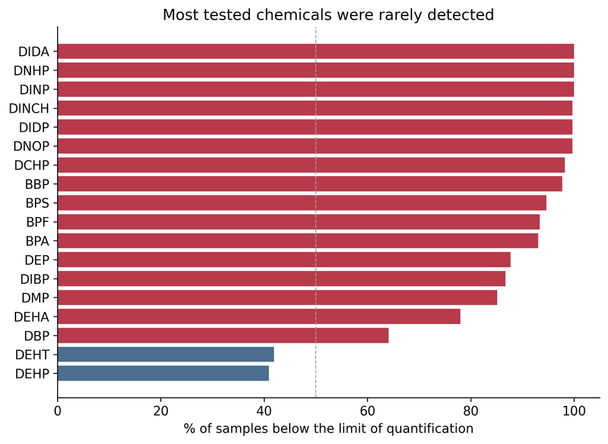

Figure 1: Detection rates across the 18 chemicals tested

```python
nondetect = nondetect_mask.mean().sort_values() * 100
nondetect.index = nondetect.index.str.replace('_ng_serving', '')

fig, ax = plt.subplots(figsize=(7.5, 5.5))
colors = [RED if v > 50 else BLUE for v in nondetect.values]
ax.barh(nondetect.index, nondetect.values, color=colors)
ax.set_xlabel('% of samples below the limit of quantification')
ax.set_title('Most tested chemicals were rarely detected')
ax.axvline(50, color=GRAY, lw=0.8, ls='--')
plt.tight_layout()
plt.show()
```

DEHP and DEHT are the only two chemicals detected in a majority of samples (roughly 59% and 58% of samples respectively cleared the LOQ). Everything else — including bisphenol A, the most famous name on this list — was undetected more often, though rates varied widely by chemical: most were undetected in 85–100% of samples, but DBP and DEHA were detected considerably more often (undetected in only 64% and 78% of samples respectively). Three chemicals (DINP, DNHP, DIDA) were never detected above the LOQ at all. Given that, the rest of this analysis focuses mostly on **DEHP**, the most commonly used plasticizer and the chemical with the most usable signal in this dataset.

## Which foods had the highest DEHP levels?

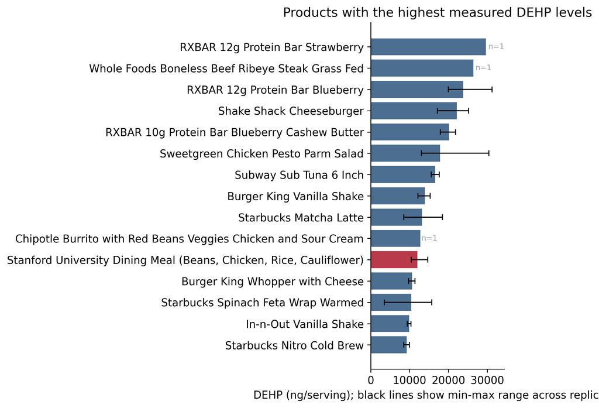

Figure 2: The 15 current-day products with the highest average DEHP per serving, with min-max replicate range where available

```python
top15 = (current.groupby('product')
         .agg(DEHP_mean=('DEHP_ng_serving', 'mean'),
              DEHP_min=('DEHP_ng_serving', 'min'),
              DEHP_max=('DEHP_ng_serving', 'max'),
              n=('DEHP_ng_serving', 'count'),
              is_stanford=('is_stanford', 'max'))
         .sort_values('DEHP_mean', ascending=False)
         .head(15)
         .sort_values('DEHP_mean'))  # ascending so the highest bar ends up on top

fig, ax = plt.subplots(figsize=(7.5, 6))
colors = [RED if v else BLUE for v in top15['is_stanford']]
ax.barh(top15.index, top15['DEHP_mean'], color=colors, zorder=2)

has_reps = top15['n'] > 1
xerr = [
    (top15['DEHP_mean'] - top15['DEHP_min']).clip(lower=0)[has_reps],
    (top15['DEHP_max'] - top15['DEHP_mean']).clip(lower=0)[has_reps],
]
ax.errorbar(top15.loc[has_reps, 'DEHP_mean'], top15.index[has_reps],
            xerr=xerr, fmt='none', ecolor='black', elinewidth=1.1, capsize=3, zorder=3)

# products tested only once can't show a range, so flag them instead of
# letting a missing error bar read as "no uncertainty"
for label in top15.index[~has_reps]:
    ax.text(top15.loc[label, 'DEHP_mean'] * 1.02, label, 'n=1', va='center',
            fontsize=8, color=GRAY)

ax.set_xlabel('DEHP (ng/serving); black lines show min-max range across replicates')
ax.set_title('Products with the highest measured DEHP levels')
ax.set_xlim(right=ax.get_xlim()[1] * 1.05)
plt.tight_layout()
plt.show()
```

Protein bars, a grass-fed ribeye, and a run of fast-casual entrees top the list. Stanford’s dining hall meal (highlighted in red) lands in 11th place among 226 current-day products — its average DEHP reading of about 12,000 ng/serving puts it in roughly the **95th percentile** of everything tested — just behind a Chipotle burrito, ahead of a Whopper with cheese, and behind the RXBAR bars and a Shake Shack cheeseburger.

The black lines are the more honest part of this chart. Where a bar has one, it’s the min-max spread across that product’s replicates, and several of them are wide enough to bump into the neighboring bar. Where a bar has no line — the top two entries and the Chipotle burrito — that’s not because the reading is more solid, it’s because the product was only tested once, so there’s nothing to compare it against.

**Note**

Before drawing conclusions from that ranking, keep reading — the section on replicate variability below shows why an 11th-place finish out of 226 shouldn’t be treated as precise.

### Do the “ahead of X, behind Y” comparisons hold up?

The ranking above is a single mean per product, which hides exactly how much the specific comparisons in that paragraph can move around. Pulling out just the items named — Stanford’s meal, the two items it beats, and the items that beat it — makes that easier to see directly.

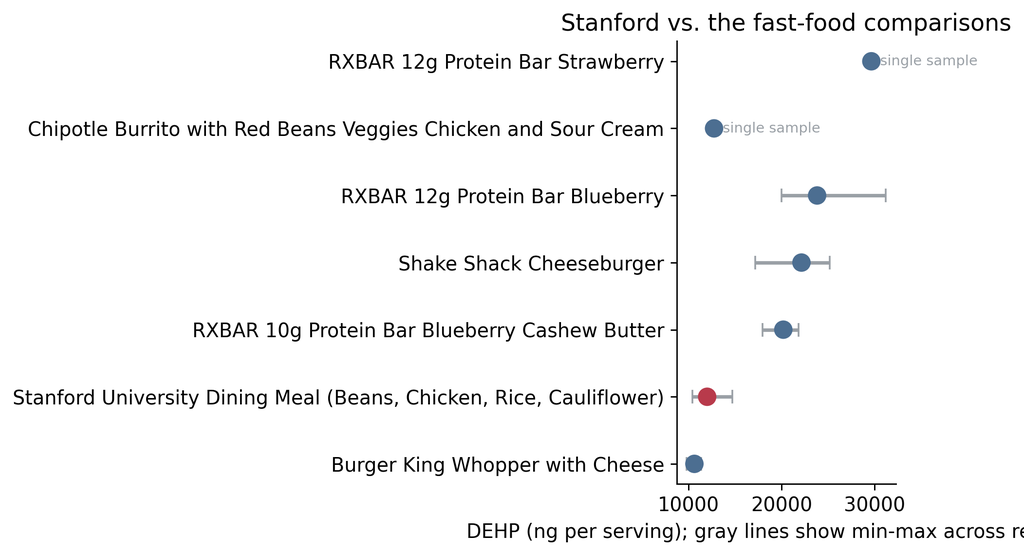

Figure 3: Mean DEHP and replicate range for Stanford’s meal and the fast-food items it’s compared against

```python
comparison_products = [
    'Stanford University Dining Meal (Beans, Chicken, Rice, Cauliflower)',
    'Chipotle Burrito with Red Beans Veggies Chicken and Sour Cream',
    'Burger King Whopper with Cheese',
    'RXBAR 12g Protein Bar Strawberry',
    'RXBAR 12g Protein Bar Blueberry',
    'RXBAR 10g Protein Bar Blueberry Cashew Butter',
    'Shake Shack Cheeseburger',
]

comp = (current[current['product'].isin(comparison_products)]
        .groupby('product')['DEHP_ng_serving']
        .agg(DEHP_mean='mean', DEHP_min='min', DEHP_max='max', n='count')
        .loc[comparison_products]
        .sort_values('DEHP_mean'))
comp['is_stanford'] = comp.index.str.startswith('Stanford')

fig, ax = plt.subplots(figsize=(7.5, 4.5))
has_reps = comp['n'] > 1
xerr = [
    (comp['DEHP_mean'] - comp['DEHP_min']).clip(lower=0)[has_reps],
    (comp['DEHP_max'] - comp['DEHP_mean']).clip(lower=0)[has_reps],
]
ax.errorbar(comp.loc[has_reps, 'DEHP_mean'], comp.index[has_reps],
            xerr=xerr, fmt='none', ecolor=GRAY, elinewidth=2, capsize=4, zorder=1)
colors = [RED if v else BLUE for v in comp['is_stanford']]
ax.scatter(comp['DEHP_mean'], comp.index, color=colors, s=90, zorder=2)

for label in comp.index[~has_reps]:
    ax.text(comp.loc[label, 'DEHP_mean'], label, '  single sample',
            va='center', fontsize=8, color=GRAY)

ax.set_xlabel('DEHP (ng per serving); gray lines show min-max across replicates')
ax.set_title('Stanford vs. the fast-food comparisons')
plt.tight_layout()
plt.show()
```

Two things stand out. First, the replicate ranges for Stanford’s meal and the Whopper actually overlap — Stanford’s low replicate (10,428 ng) sits below the Whopper’s high replicate (11,376 ng) — so “Stanford ahead of the Whopper” is a real pattern but a close one, not a clean separation. Second, Chipotle and one of the three RXBAR flavors were each tested only once, meaning the comparisons against them rest partly on single readings with no replicate check behind them at all — those single readings could plausibly land anywhere in the same range the *other* products’ replicates show. That matters most for the Chipotle comparison: Stanford’s mean sits only about 6% below Chipotle’s one reading (12,749 ng), close enough that a different Chipotle sample could easily have landed on either side of it. The comparisons hold up directionally, but the margins are narrower than a one-line ranking suggests.

We excluded one category from this chart on purpose. PlasticList also tested a small batch of vintage items as a curiosity — mostly 1950s–60s military rations, plus a few older grocery and household products from as far back as the 1920s — and one of them, powdered milk from 1952 Korean War rations, came back with a DEHP reading of roughly **1.5 million ng/serving**: about 23 times higher than the next-highest reading anywhere in the dataset (a 1952 cracker sample, also from the vintage batch) and nearly 50 times higher than the highest current-day product. Whether that reflects seven decades of packaging degradation, a counterfeit product, or a lab artifact is genuinely unclear, and PlasticList says as much in their own writeup. It’s a fun data point, but not a useful comparison for a 2026 grocery run, so it’s excluded from the “current day” figures throughout.

## Does food category predict contamination?

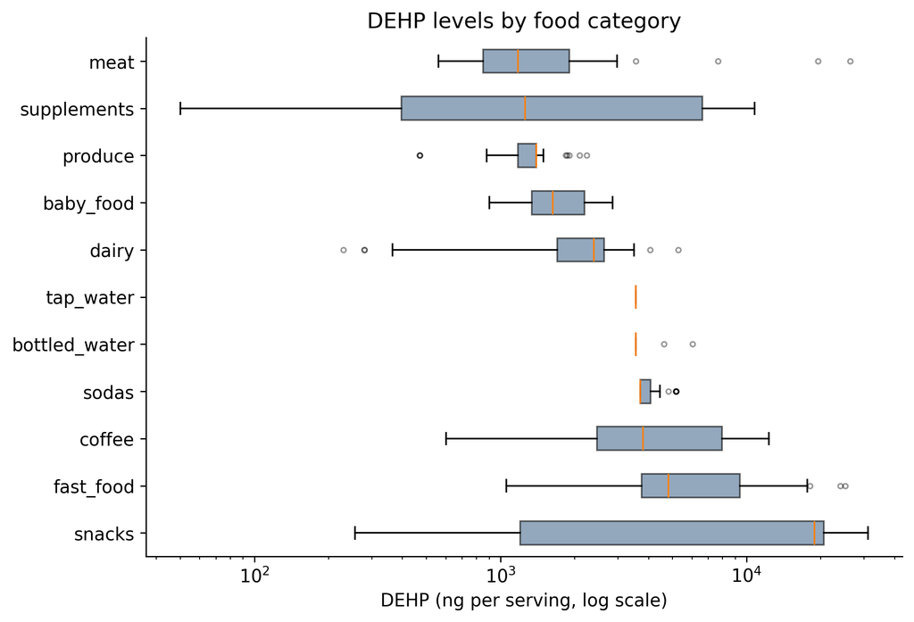

Figure 4: DEHP levels by food category (log scale)

```python
tag_priority = ['baby_food', 'fast_food', 'meat', 'dairy', 'produce', 'coffee',
                 'sodas', 'bottled_water', 'tap_water', 'supplements', 'snacks']

def assign_category(tags):
    if pd.isna(tags):
        return 'other'
    tagset = set(t.strip() for t in tags.split(','))
    for t in tag_priority:
        if t in tagset:
            return t
    return 'other'

current['category'] = df.loc[current.index, 'tags'].apply(assign_category)
plot_df = current[(current['category'] != 'other') & (current['DEHP_ng_serving'] > 0)]
order = plot_df.groupby('category')['DEHP_ng_serving'].median().sort_values(ascending=False).index

fig, ax = plt.subplots(figsize=(8, 5.5))
box_data = [plot_df.loc[plot_df['category'] == c, 'DEHP_ng_serving'].values for c in order]
bp = ax.boxplot(box_data, vert=False, tick_labels=order, patch_artist=True,
                 flierprops=dict(marker='o', markersize=3, alpha=0.4))
for patch in bp['boxes']:
    patch.set_facecolor(BLUE)
    patch.set_alpha(0.6)
ax.set_xscale('log')
ax.set_xlabel('DEHP (ng per serving, log scale)')
ax.set_title('DEHP levels by food category')
plt.tight_layout()
plt.show()
```

Snack bars and fast food sit at the top; produce, supplements, and meat sit at the bottom. That ordering roughly matches what PlasticList itself reported: less-processed foods like produce and meat tend to show less frequent and lower-magnitude contamination than heavily processed items that pass through more equipment and packaging on the way to a plate. Water doesn’t fit that story here, though — both tap and bottled water actually land in the middle of this ordering, above produce, meat, and supplements. As the next section shows, that’s most likely the LOQ-substitution artifact at work (most water samples are non-detects assigned the same threshold value) rather than a real contamination signal, so water shouldn’t be read as either confirming or breaking the “less-processed means less contamination” pattern. For the solid foods, it’s a plausible story — more processing steps mean more contact surfaces — but this dataset can only show the association, not confirm that processing itself is the cause.

## Tap water vs. bottled water

Water testing was one of PlasticList’s more closely watched threads, since it’s something almost everyone drinks daily.

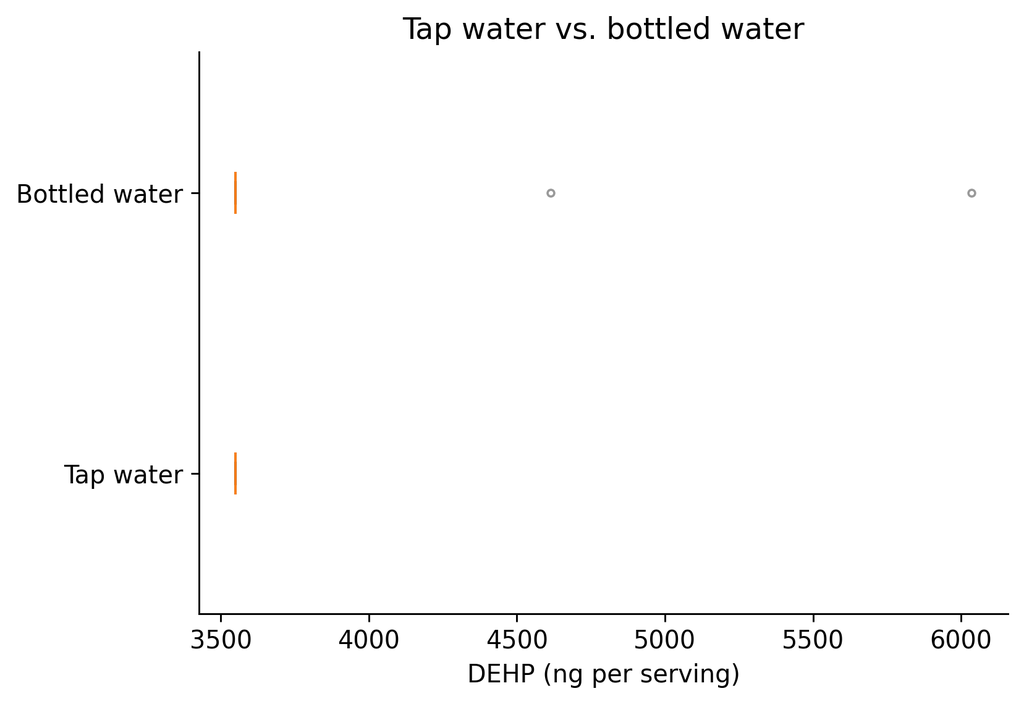

Figure 5: Tap water vs. bottled water

```
category
bottled_water    3550.0
tap_water        3550.0
Name: DEHP_ng_serving, dtype: float64
```

```python
water = current[current['category'].isin(['tap_water', 'bottled_water'])]

fig, ax = plt.subplots(figsize=(6.5, 4.5))
water_data = [water.loc[water['category'] == c, 'DEHP_ng_serving'].values
              for c in ['tap_water', 'bottled_water']]
bp = ax.boxplot(water_data, vert=False, tick_labels=['Tap water', 'Bottled water'],
                 patch_artist=True, flierprops=dict(marker='o', markersize=3, alpha=0.4))
for patch, c in zip(bp['boxes'], [BLUE, RED]):
    patch.set_facecolor(c)
    patch.set_alpha(0.6)
ax.set_xlabel('DEHP (ng per serving)')
ax.set_title('Tap water vs. bottled water')
plt.tight_layout()
plt.show()

print(water.groupby('category')['DEHP_ng_serving'].median())
```

Both categories land on the exact same median value — which is a tell, not a coincidence. The median for both groups is sitting right at the LOQ, meaning more than half of both tap and bottled samples were non-detects that got assigned the same threshold value during cleaning. This is a case where the data genuinely can’t distinguish tap from bottled water on DEHP alone; saying more would require the finer-grained detection information that got collapsed away by the `_ng_serving` cleaning step.

## How much do repeat tests of the same product agree?

This is the section that most directly explains why PlasticList — and this writeup — avoid strong claims about individual products. Most products were tested three times, and those replicates don’t always land close together.

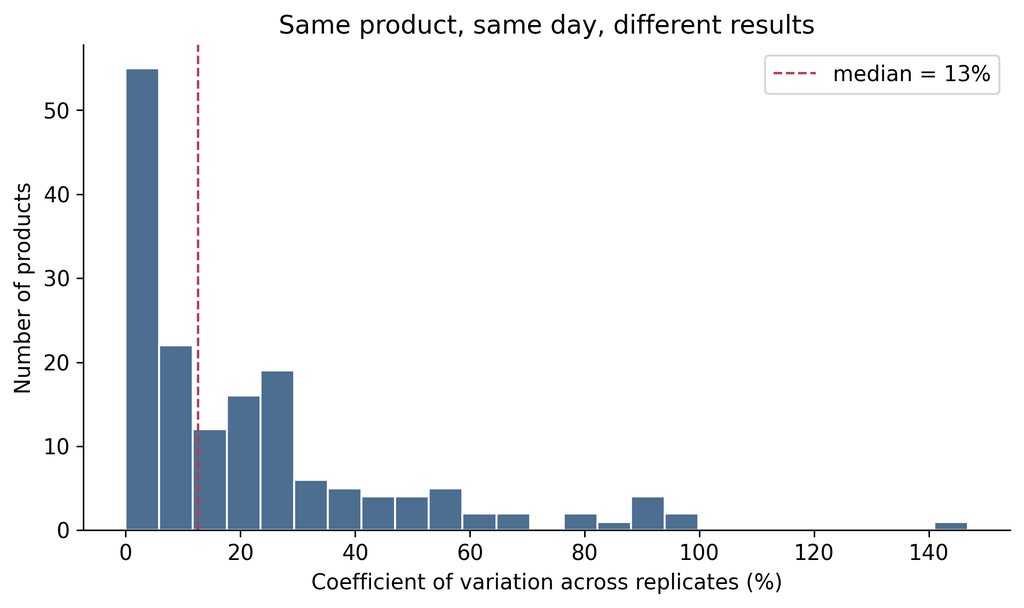

Figure 6: Replicate-to-replicate variability in DEHP measurements

```
n = 162 products with 3+ replicates
median CV: 12.6%, mean CV: 21.5%
```

```python
counts = current.groupby('product')['DEHP_ng_serving'].count()
multi = counts[counts >= 3].index
rep = current[current['product'].isin(multi)].groupby('product')['DEHP_ng_serving'].agg(['mean', 'std'])
rep['cv_pct'] = rep['std'] / rep['mean'] * 100
rep = rep.dropna()

fig, ax = plt.subplots(figsize=(7.5, 4.5))
ax.hist(rep['cv_pct'], bins=25, color=BLUE, edgecolor='white')
ax.axvline(rep['cv_pct'].median(), color=RED, ls='--', lw=1.2,
           label=f"median = {rep['cv_pct'].median():.0f}%")
ax.set_xlabel('Coefficient of variation across replicates (%)')
ax.set_ylabel('Number of products')
ax.set_title('Same product, same day, different results')
ax.legend()
plt.tight_layout()
plt.show()

print(f"n = {len(rep)} products with 3+ replicates")
print(f"median CV: {rep['cv_pct'].median():.1f}%, mean CV: {rep['cv_pct'].mean():.1f}%")
```

For a typical product, replicate measurements differ from each other by about 13% (the median coefficient of variation). But the distribution has a long right tail: for roughly a tenth of products, replicates disagreed by more than 60%, and for one — a boneless ribeye steak — replicate readings varied by more than the average value itself; a couple of others, including a canned tuna product, came close without quite crossing that line. Stanford’s dining meal is a good concrete example: its three replicates measured 10,428, 10,902, and 14,694 ng of DEHP, a swing of about 36% around the mean. A “95th percentile” ranking for that meal is real, but it comes with real uncertainty attached, and a different set of three samples on a different day might well rank differently.

That raises a natural follow-up: is the noise related to how much DEHP a product has in the first place, or is it scattered evenly across low- and high-concentration products alike?

[figure not shown]

Figure 7: Replicate variability against concentration, for products with 3+ replicates

```python
fig, ax = plt.subplots(figsize=(7.5, 5))
rep_join = rep.join(current.groupby('product')['is_stanford'].max())
colors = [RED if v else BLUE for v in rep_join['is_stanford']]
sizes = [45 if v else 20 for v in rep_join['is_stanford']]
alphas = [0.9 if v else 0.45 for v in rep_join['is_stanford']]
for x, y, c, s, a in zip(rep_join['mean'], rep_join['cv_pct'], colors, sizes, alphas):
    ax.scatter(x, y, color=c, s=s, alpha=a, edgecolor='none')

stanford_row = rep_join[rep_join['is_stanford']]
if len(stanford_row):
    ax.annotate('Stanford meal', (stanford_row['mean'].iloc[0], stanford_row['cv_pct'].iloc[0]),
                textcoords='offset points', xytext=(8, 6), fontsize=9, color=RED)

ax.set_xscale('log')
ax.set_xlabel('Mean DEHP per product (ng/serving, log scale)')
ax.set_ylabel('Coefficient of variation across replicates (%)')
ax.set_title('Noisier at low concentrations, not at high ones')
plt.tight_layout()
plt.show()
```

## A closer look at Stanford Dining

Four samples in this dataset were collected from Arrillaga Family Dining Commons on campus: one water sample and three replicates of a beans-chicken-rice-cauliflower meal. The three meal replicates were all collected on the same day; the water sample’s collection date wasn’t recorded, so it can’t be confirmed to be from that same visit.

```python
stanford_cols = ['product', 'collected_on', 'DEHP_ng_serving', 'BPA_ng_serving']
data.loc[data['is_stanford'], stanford_cols].reset_index(drop=True)
```

Table 1

|  | product | collected_on | DEHP_ng_serving | BPA_ng_serving |
| --- | --- | --- | --- | --- |
| 0 | Stanford University Dining Hall Water | NaN | 3550.0 | 355.0 |
| 1 | Stanford University Dining Meal (Beans, Chicke... | 2024-08-07 | 10902.0 | 758.4 |
| 2 | Stanford University Dining Meal (Beans, Chicke... | 2024-08-07 | 10428.0 | 474.0 |
| 3 | Stanford University Dining Meal (Beans, Chicke... | 2024-08-07 | 14694.0 | 521.4 |

The dining hall water sample came back below the limit of quantification for DEHP, consistent with the pattern seen in tap and bottled water more broadly. The meal is the more interesting data point: it averaged about 12,000 ng of DEHP per serving, placing it in the 95th percentile of all current-day items tested and higher than several fast food comparisons, including a Whopper with cheese — though it narrowly trails a Chipotle burrito, one of the closest comparisons in the dataset. It’s worth being precise about what that does and doesn’t mean. This is one meal, tested on one day, at one dining hall, out of the dozens Stanford operates — it says nothing about other dining halls, other meals, or how consistent this particular meal is over time. Given the replicate variability shown above, even this single meal carries a real margin of error. It’s a data point worth Stanford Dining’s attention, not a verdict on campus food safety.

## Limitations

A few caveats apply to everything above, echoing PlasticList’s own framing of this data:

- **Small samples, no peer review.** Most products were tested three times; some chemicals were tested with methods that weren’t independently validated the way an academic study’s would be.
- **Non-detects are approximated, not zero.** As noted above, values below the LOQ are recorded as the LOQ itself, which biases both detection rates and average concentrations upward for rarely-detected chemicals.
- **A snapshot, not a trend.** Almost everything here was collected within a short window in 2024; it says nothing about whether levels are rising, falling, or seasonal.
- **Association, not mechanism.** The category patterns (processed vs. less-processed foods) are descriptive. This dataset can’t tell us why the pattern exists.
- **ng/serving isn’t a health verdict.** Nothing here is compared against a regulatory or toxicological safety threshold — those columns existed in the original data but were intentionally excluded by the cleaning step used for this assignment.

*Data: [PlasticList](https://www.plasticlist.org/), accessed via the course-provided mirror. Analysis and code in this repository are independent of PlasticList and Stanford University.*